# State Happiness Analysis Using Twitter Data

Susmita Ghose

Monday, November 03, 2014

In this document, the happiness score that was obtained is analyzed and it’s correlation to several demographic factors is studied.

```r
# First the table obtained is cleaned for downstream processing
data<-read.table("./happiness.txt", sep = ",", )
#data<-read.table("./op.txt", sep = ",")
states<-character(dim(data)[2])
happiness_score<-numeric(dim(data)[2])
for(i in 1:dim(data)[2])
{
    dict<-strsplit(as.character(data[,i]), ":")
    dict[[1]][1]<-sub("\\{", "", dict[[1]][1] )
    dict[[1]][2]<-sub("\\}", "", dict[[1]][2])
    states[i]<-as.character(dict[[1]][1])
    happiness_score[i]<-as.numeric(dict[[1]][2])
    states[i]<-gsub("^\\s+|\\s+$", "", states[i])
    states[i]<-tolower(states[i])
}

happiness_data<-data.frame(states,happiness_score)
happiness_data<-happiness_data[order(happiness_score),]
```

A geographical map of the happiness score is created.

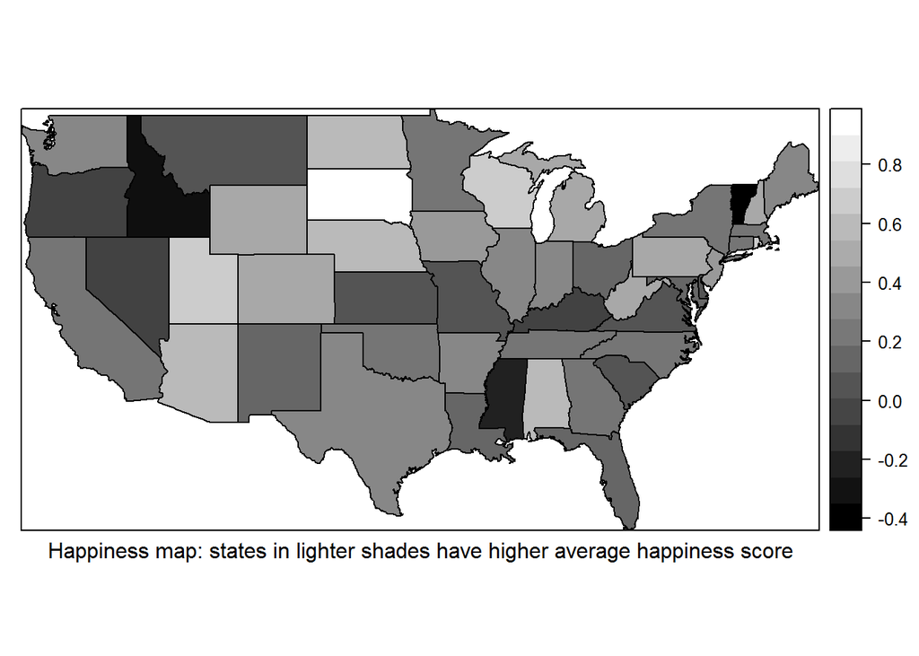

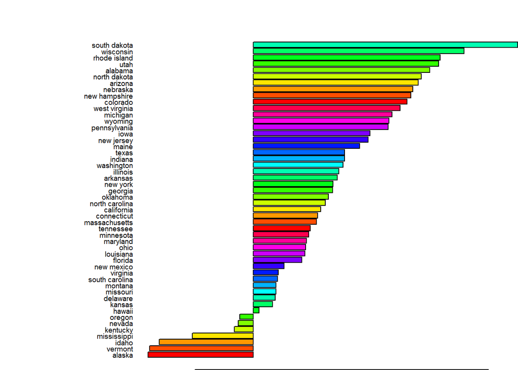

```r
# Population density data is obtained from: http://en.wikipedia.org/wiki/List_of_U.S._states_by_population_density#Summary_of_density_by_region_showing_population_and_land_area

pop_density = read.csv("./pop_data/pop_density.csv", header = FALSE)
pop_density<-pop_density[, 1:2]
names(pop_density)<- c("State", "pop_density_per_sq_mile")
pop_density[,1]<-tolower(pop_density[,1])
merged_data<-merge(happiness_data, pop_density, by.x="states", by.y = "State" )
merged_data$happiness_score<-as.numeric(merged_data$happiness_score)
merged_data$pop_density_per_sq_mile<-as.numeric(merged_data$pop_density_per_sq_mile)

# Next set of demographic data is downloaded from https://www.census.gov/popest/data/state/asrh/2013/files/SCPRC-EST2013-18+POP-RES.csv
pop_data<-read.csv("./pop_data/pop.csv")
pop_data<-pop_data[, 5:8]
pop_data[,1]<-tolower(pop_data[,1])
names(pop_data)<-c("NAME", "pop_2013", "pop_greater_than_age_18", "perc_pop_greater_than_age_18")
pop_data$pop_2013<-as.numeric(as.character(pop_data$pop_2013))
pop_data$perc_pop_greater_than_age_18<-as.numeric(as.character(pop_data$perc_pop_greater_than_age_18))
pop_data<-pop_data[, c(1,4)]
merged_data<-merge(merged_data, pop_data, by.x="states", by.y = "NAME")
merged_data<-merged_data[, -5]

# The next set of data is obtained from http://factfinder2.census.gov/faces/tableservices/jsf/pages/productview.xhtml?src=bkmk
dem_data<-read.csv("./pop_data/dem_data.csv")
dem_data<-subset(dem_data, dem_data$Year.display.label == "April 1, 2010 Census" &
                    dem_data$Sex.display.label=="Both Sexes" & Hisp.display.label=="Total")
dem_data<-dem_data[-1,]
dem_data<-dem_data[, c('GEO.display.label', 'totpop', 'wa', 'aa', 'ba') ]
dem_data$perc_white<-100*as.numeric(as.character(dem_data$wa))/as.numeric(as.character(dem_data$totpop))
dem_data$perc_asian<-100*as.numeric(as.character(dem_data$aa))/as.numeric(as.character(dem_data$totpop))
dem_data<-dem_data[, c('GEO.display.label', 'perc_white', 'perc_asian')]
dem_data$GEO.display.label<-tolower(dem_data$GEO.display.label)
merged_data<-merge(merged_data, dem_data, by.x="states", by.y = "GEO.display.label")

# Education data is obtained from: http://www.census.gov/compendia/statab/cats/education/educational_attainment.html
suppressWarnings(suppressMessages(library(gdata)))
edu_data<-read.xls("./pop_data/educational_attainment.xls", header=T, skip=4)
edu_data<-edu_data[, c(1,20:22)] # most current information
edu_data$X<-tolower(edu_data$X)
names(edu_data)<-c("X", "perc_high_school_graduate_or_more", "perc_bachelors_degree_or_more", "perc_advanced_degree_or_more" )
merged_data<-merge(merged_data, edu_data, by.x="states", by.y = "X")

# Life Expectancy data is obtained from http://kff.org/other/state-indicator/life-expectancy/
# Also verified at http://www.cdc.gov/nchs/fastats/life-expectancy.htm

life_data<-read.csv("./pop_data/life_expectancy.csv", header=T, skip=3)
life_data$Location<-tolower(life_data$Location)
names(life_data)<-c("Location", "life_expectancy_at_birth_years")
merged_data<-merge(merged_data, life_data, by.x="states", by.y = "Location")

# Divorce data was obtained from http://www.census.gov/compendia/statab/cats/births_deaths_marriages_divorces/marriages_and_divorces.html
divorce_data<-read.xls("./pop_data/marriages_divorces.xls", header=T, skip=6)
divorce_data<-divorce_data[, c(1,33)] # most current information
f<-function(x){sub(' \\\\[0-9]', "", x)}  # remove \\
divorce_data$X<-sapply(divorce_data$X, f)
divorce_data<-divorce_data[2:52,]
divorce_data$X<-tolower(divorce_data$X)
names(divorce_data)<-c("X", "divorce_rate_per_1000")
divorce_data$divorce_rate_per_1000<-as.numeric(as.character(divorce_data$divorce_rate_per_1000))
merged_data<-merge(merged_data, divorce_data, by.x="states", by.y = "X")

# Poverty data: https://www.census.gov/hhes/www/poverty/data/incpovhlth/2013/tables.html
poverty_data<-read.xls("./pop_data/poverty_rate.xls", header=T, skip=8)
poverty_data<-poverty_data[,1:2]
poverty_data<-poverty_data[2:52,]
f<-function(x){gsub('\\.', "", x)}
poverty_data$X<-sapply(poverty_data$X, f)
poverty_data$X<-tolower(poverty_data$X)
names(poverty_data)<-c("X", "perc_pop_in_poverty")
merged_data<-merge(merged_data, poverty_data, by.x="states", by.y = "X")

# Income data: https://www.census.gov/hhes/www/income/data/statemedian/
income_data<-read.xls("./pop_data/median_income.xls", header=T)
income_data$state<-tolower(income_data$state)
income_data$median_income<-as.character(income_data$median_income)
f<-function(x){sub(",", "", x)}
income_data$median_income<-sapply(income_data$median_income, f)
income_data$median_income<-as.numeric(income_data$median_income)/1000
names(income_data)<-c("X", "income_thosands_of_dollars")
merged_data<-merge(merged_data, income_data, by.x="states", by.y = "X")

# Obesity data is obtained from http://www.cdc.gov/obesity/data/table-adults.html
obesity_data<-read.table("./pop_data/obesity_percentage.txt", header=F, sep ='\t')
obesity_data<-obesity_data[, 1:2]
obesity_data$V1<-tolower(obesity_data$V1)
names(obesity_data)<-c("state", "obesity_percentage")
merged_data<-merge(merged_data, obesity_data, by.x="states", by.y = "state")

# Labor statistics is obtained from http://www.census.gov/compendia/statab/cats/labor_force_employment_earnings/labor_force_status.html which gets the data from US Bureau of Labor Statistics
labor_data<-read.xls("./pop_data/labor_force.xls", header=T, skip=4)
labor_data<-labor_data[, c(1,4:5)]
labor_data$Total<-as.character(labor_data$Total)
f<-function(x){sub(",", "", x)}
labor_data$Total<-sapply(labor_data$Total, f)
labor_data$Female.1<-as.character(labor_data$Female.1)
labor_data$Female.1<-sapply(labor_data$Female.1, f)
labor_data$perc_women_in_labor_force<-100*as.numeric(labor_data$Female.1)/as.numeric(labor_data$Total)
labor_data<-labor_data[2:53, c(1,4)]
labor_data$X<-tolower(as.character(labor_data$X))
labor_data$X<-gsub("^\\s+|\\s+$", "", labor_data$X)
merged_data<-merge(merged_data, labor_data, by.x="states", by.y = "X")


# Crime data is obtained from: http://www.fbi.gov/about-us/cjis/ucr/crime-in-the-u.s/2012/crime-in-the-u.s.-2012/resource-pages/download-printable-files
crime_data<-read.xls("./pop_data/Table_4_Crime_in_the_United_States_by_Region_Geographic_Division_and_State_2011-2012.xls", header=T, skip=3)
crime_data<-crime_data[crime_data$Year==2012,]
crime_data<-crime_data[, c(1,5)]
crime_data$Area<-tolower(crime_data$Area)
names(crime_data)<-c("states", "crime_rate_per_100K")
f<-function(x){sub(",", "", x)}
crime_data$crime_rate_per_100K<-sapply(crime_data$crime_rate_per_100K, f)
crime_data$crime_rate_per_100K<-as.numeric(as.character(crime_data$crime_rate_per_100K))
crime_data$states<-gsub("^\\s+|\\s+$", "", crime_data$states)
merged_data<-merge(merged_data, crime_data, by="states", by.y = "states")
```

Summarize the findings with a few plots and correlation of the demographic factors.

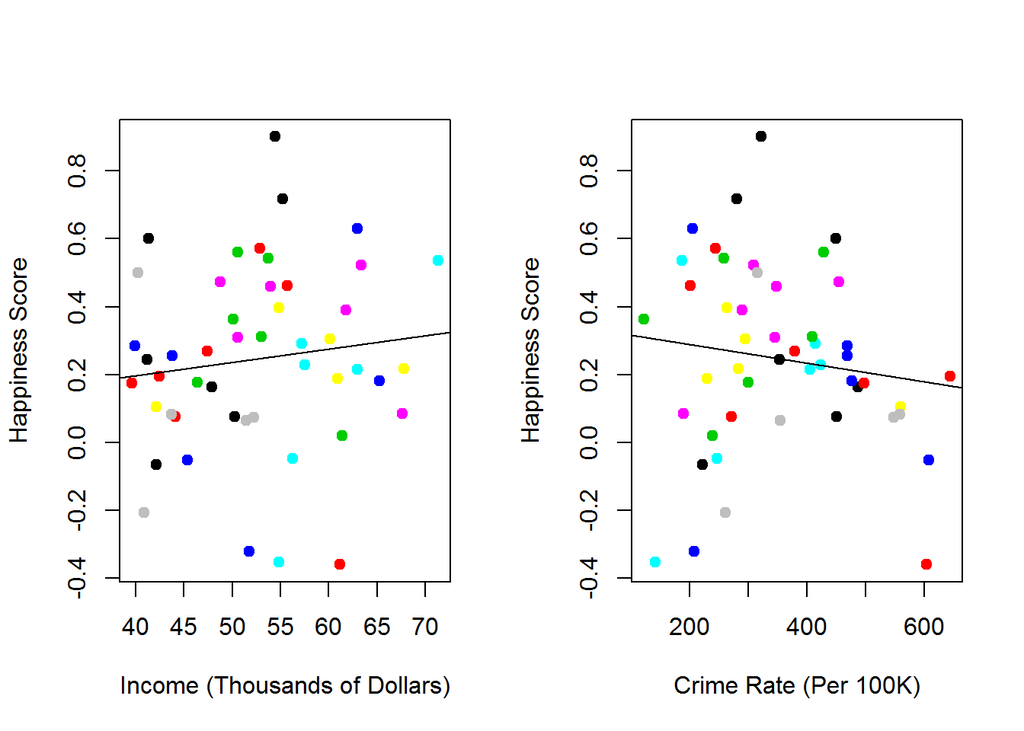

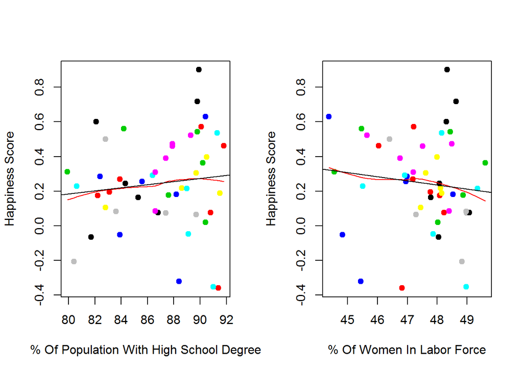

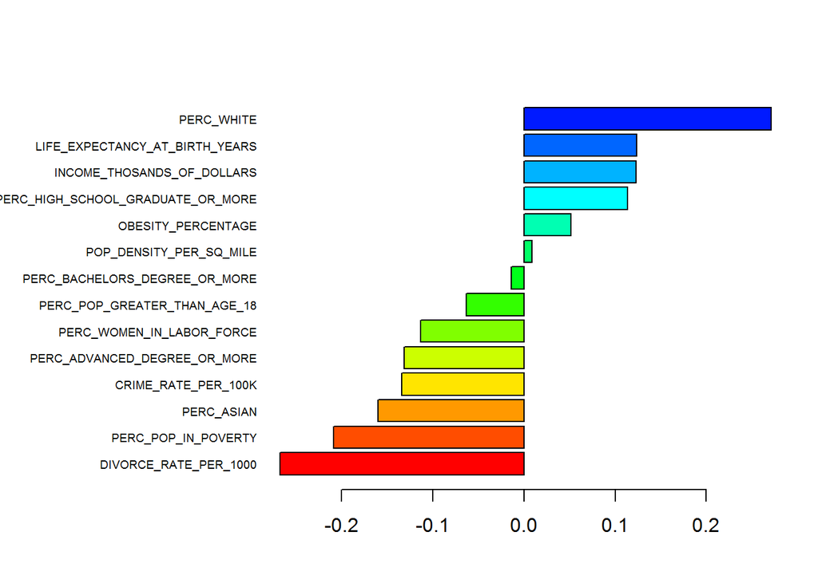

```r
happiness_value<-merged_data$happiness_score
demographic_factors<-merged_data[, 3:dim(merged_data)[2]]
corr<-function(x)(cor(happiness_value,x, use="pairwise"))
corr_data<-data.frame(corr_value=t(corr(demographic_factors)), demographic_factors=names(demographic_factors))
corr_data<-corr_data[order(corr_data$corr_value),]
par(mfrow=c(1,1), mar= c(4, 12, 4, 2))
barplot(corr_data$corr_value, names.arg=toupper(corr_data$demographic_factors),horiz=TRUE, las=1, cex.names=0.6, col=rainbow(20))
```

This study has a few inherent limitations:

1. The amount of Twitter data used for this analysis is not sufficient. Greater amounts of data spreading across several days/weeks should be used to obtain more meaningful results.
2. As of January 2014, only 19% of online adults use Twitter (http://www.pewinternet.org/fact-sheets/social-networking-fact-sheet/) which is very low and hence the data may not be representative of the general population. Analysis should be rerun in later years the usage is much higher.
3. Some of the demographic data sets are not current. (For example, the educational data is from 2009)